# RNetica Introduction

6/3/2021

## RNetica and Peanut Packages

## The RNetica Packages

The RNetica suite consists of a number of packages:

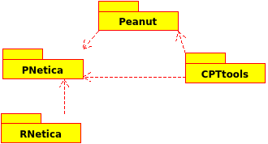

RNetica Package Suite

1. `CPTtools` is a collection of tools for building conditional probability tables (particularly, the DiBello models). It stands alone.
2. `RNetica` links R to the [Netica](https://norsys.com) Bayes net engine. _Note: non-trivial uses of RNetica require a Netica API (not GUI) license from [Norsys](https://norsys.com).

## Peanut packages

The Peanut object oriented framework rests on top of `CPTtools` and `RNetica`.

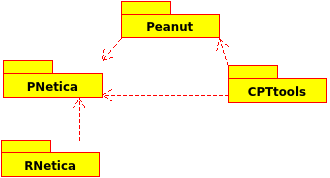

RNetica Package Suite

1. `Peanut` (a corrupt reading of Pnet, or parameterized network) is an object oriented frame work on top of `CPTtools`.
2. `PNetica` is an implementation of the `Peanut` framework using `RNetica`.

*Packages must be installed in this order!*

## Installation Preliminaries

You can install the packages from source or (Windows and Mac OS only) from precompiled binaries.

Compiling packages from source require installing the proper compilers. Instructions can be found at [Windows](https://cloud.r-project.org/bin/windows/Rtools/) or [Mac OS](https://mac.r-project.org/tools/).

The following packages are used by the PNetica software and should be installed (usual CRAN mirror) before starting.

```r
install.packages(c("R.utils","futile.logger",
                   "shiny","shinyjs", "ggplot2", "lattice"),
                 repos="https://cloud.r-project.org/")
```

You can also install these packages using the RStudio `Tools > Install Packages` menu item.

## Installation Method 1 – Precompiled tarballs

This method is available only for Windows and Mac OS.

Download the compiles packages (`.zip` files for Windows, `.tgz` files for MacOS) from https://pluto.coe.fsu.edu/RNetica (follow the links there for the latest version). Make sure to grab all four tarballs.

Windows : CPTtools_0.7-2.zip RNetica_0.8-4.zip Peanut_0.8-4.zip  
PNetica_0.8-5.zip

MacOS: CPTtools_0.7-2.tgz RNetica_0.8-4.tgz Peanut_0.8-4.tgz PNetica_0.8-5.tgz

## install.packages and R CMD INSTALLATION

To install the packages using R Studio, select the “Tools > Install Packages” menu item, then select “Local Package Archive” from the first “Install from” drop down.

You can also use this command:

```r
install.packages(file.choose())
```

Finally, if you open a terminal window, you can run the command `R CMD INSTALL <packagefile>` to install the package.

*Packages must be installed in order!*

## Installation Method II – Source and Github

All of the packages are currently available on [Github](https://github.com/ralmond).

Installing RNetica from github requires the appropriate compilers (Rtools or Xcode) installed on your system.

```r
#uncomment first line if needed.
#install.packages("devtools",repos="https://cloud.r-project.org")
library(devtools)
install_github("ralmond/CPTtools")
install_github("ralmond/RNetica")
install_github("ralmond/Peanut")
install_github("ralmond/PNetica")
```

## Netica and R

## License

- R – GPL-3 (Free and open source)
- RNetica – Artistic (Free and open source)
- Netica.dll/libNetica.so– Commercial (open API, but not open source)
  - Free Student/Demo version
    - Limited number of nodes
    - Limited usage (education, evaluation of Netica)
  - Paid version (seehttp://www.norsys.com/for price information)
    - Need to purchase API not GUI version ofNetica
    - May want both (use GUI to visualize networks built in RNetica)
- CPTtools, Peanut – Artistic (Free and open source), does not depend on Netica
- RNetica – Artistic, but depends on RNetica.

## Installing the License Key

- When you purchase a license, Norsys will send you a license key. Something that looks like:

  “+Course/FloridaSU/Ex15-05-30,120,310/XXXXX”

  (Where I’ve obscured the last 5 security digits)

To install the license key, start R in your project directory and type:

```r
NeticaLicenseKey <- “+Course/FloridaSU/Ex15-05-30,120,310/XXXXX”
q(“yes”)
```

Can also put first line in file in your home directory and run `source("~/NeticaLicense.R")` every time you run RNetica.

## Starting RNetica

After you load RNetica you need to start the session. This is when you pass the license key.

```r
library(RNetica)
sess <- NeticaSession(LicenseKey=NeticaLicenseKey)
startSession(sess)
```

```r
library(RNetica)
sess <- NeticaSession()
startSession(sess)
```

```
## Netica 6.07 Linux (AFCl64), (C) 1992-2019 Norsys Software Corp.
##
## Netica is operating without a password; there are some limitations.
```

Everything in this tutorial should run without the license.

## When to use the session object.

- When starting/restarting Netica
- When creating a network, or reading one from a file.
- When searching for networks.
- Certain global properties

`NeticaBN` objects have a `$session` proprty which points back to the session.

`NeticaNode` objects have a `$node` property which points back to the network (which points to the session).

## The R heap and the Netica heap

R and Netica have two different workspaces (memory heaps)

R workspace is saved and restored automatically when you quick and restart R.

Neticaheap must be reconnected manually.

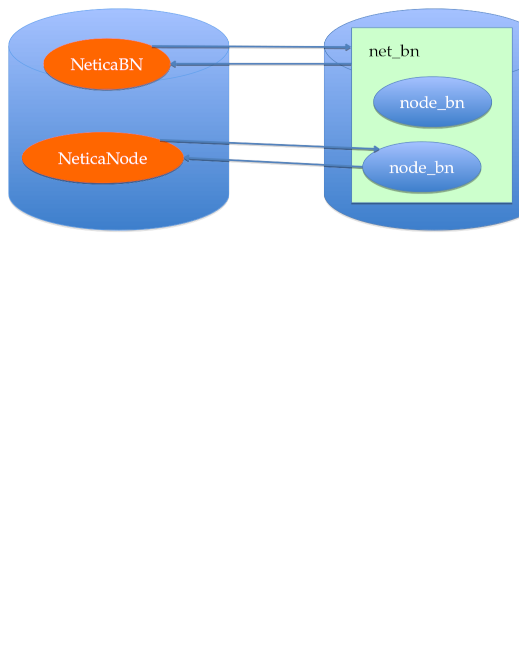

R and Netica Heaps

## Active and Inactive pointers

When RNetica creates/finds aNeticaobject it creates a corresponding R object

If the R object is active then it points to the Netica object, and the Netica object points back at it.

If the pointer gets broken (saving and restarting R, deleting the network/node then the R object becomes inactive.

The function `is.active(nodeOrNet)` test to see if the node/net is active.

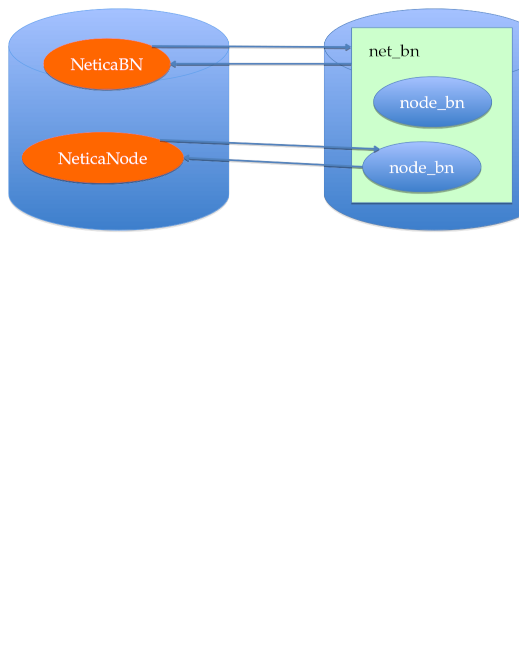

R and Netica Heap

## Mini-ACED

## Mini-ACED Proficiency model

Subset of ACED network: Shute, Hansen & Almond (2008); http://ecd.ralmond.net/ecdwiki/ACED

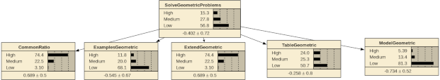

Proficiency Model

## Mini-ACED EM Fragments

All ACED tasks were scored correct/incorrect

Each evidence model is represented by a fragment consisting of observables with *stub* edges indicating where it should be *adjoined* with the network.

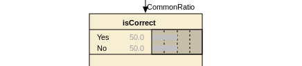

Common Ratio Easy

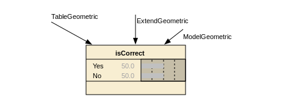

Model Table Extend Hard

## Task to EM map

Need a table to tell us which EM to use with which task

```r
## Read in task->evidence model mapping
EMtable <- read.csv("miniACED/MiniACEDEMTable.csv",row.names=1,
                    as.is=2) #Keep EM names as strings
EMtable
```

```
##                                                  EM    X   Y
## tCommonRatio1a                    CommonRatioEasyEM  108 294
## tCommonRatio1b                    CommonRatioEasyEM  108 414
## tCommonRatio2a                     CommonRatioMedEM  108 534
## tCommonRatio2b                     CommonRatioMedEM  108 654
## tCommonRatio3a                    CommonRatioHardEM  108 774
## tCommonRatio3b                    CommonRatioHardEM  108 894
## tExamplesGeometric1a                 ExamplesEasyEM  342 294
## tExamplesGeometric1b                 ExamplesEasyEM  342 414
## tExamplesGeometric2a                  ExamplesMedEM  342 534
## tExamplesGeometric2b                  ExamplesMedEM  342 654
## tExamplesGeometric3a                 ExamplesHardEM  342 774
## tExamplesGeometric3b                 ExamplesHardEM  342 894
## tExtendGeometric1a                     ExtendEasyEM  588 294
## tExtendGeometric1b                     ExtendEasyEM  588 414
## tExtendGeometric2a                      ExtendMedEM  588 534
## tExtendGeometric2b                      ExtendMedEM  588 654
## tExtendGeometric3a                     ExtendHardEM  588 774
## tExtendGeometric3b                     ExtendHardEM  588 894
## tTableExtendGeometric1a           TableExtendEasyEM 1134 282
## tTableExtendGeometric1b           TableExtendEasyEM 1134 402
## tTableExtendGeometric2a            TableExtendMedEM 1134 522
## tTableExtendGeometric2b            TableExtendMedEM 1134 642
## tTableExtendGeometric3a           TableExtendHardEM 1134 762
## tTableExtendGeometric3b           TableExtendHardEM 1134 882
## tModelExtendTableGeometric1a ModelTableExtendEasyEM  858 288
## tModelExtendTableGeometric1b ModelTableExtendEasyEM  858 408
## tModelExtendTableGeometric2a  ModelTableExtendMedEM  858 528
## tModelExtendTableGeometric2b  ModelTableExtendMedEM  858 648
## tModelExtendTableGeometric3a ModelTableExtendHardEM  858 768
## tModelExtendTableGeometric3b ModelTableExtendHardEM  858 888
```

## Scoring Script

## Preliminaries

The following script assumes that the data files it needs are in the folder `miniACED` and that this folder is in the same directory as this `Rmd` file.

Don’t forget to `setwd()` to the `miniACED` folder (as it needs to find its networks).

```r
## Scoring Script
## Preliminaries
library(RNetica)

sess <- NeticaSession()
startSession(sess)
```

```
## Netica environment is already initialized
```

## Read in the Network.

```r
## Read in network -- Do this every time R is restarted
profModel <- ReadNetworks("miniACED/miniACEDPnet.dne",session = sess)
## If profModels already exists could also use

## Reconnect nodes -- Do this every time R is restarted
allNodes <- NetworkAllNodes(profModel)
sgp <- allNodes$SolveGeometricProblems
sgp
```

```
## Discrete  Netica Node named  SolveGeometricProblems in network  MiniACEDPM
##   Node is currently active.
## States are:  High, Medium, Low
```

## Aside 1 – Node Sets

Node sets can be viewed as either

A. a set of labels assigned to each node.

B. a set of nodes which have a particular label.

In RNetica, these are very useful as they define collections of nodes that might be interesting in some way (e.g., Proficiency variables, Observable variable, background variables)

Node set operations yeild a list of nodes; iterating over that set is often very useful.

## Node Set Examples

```r
## Node Sets
NetworkNodeSets(profModel)
```

```
## [1] "pnodes"        "Proficiencies"
```

```r
NetworkNodesInSet(profModel,"pnodes")
```

```
## $TableGeometric
## Discrete  Netica Node named  TableGeometric in network  MiniACEDPM
##   Node is currently active.
## States are:  High, Medium, Low
##
## $ModelGeometric
## Discrete  Netica Node named  ModelGeometric in network  MiniACEDPM
##   Node is currently active.
## States are:  High, Medium, Low
##
## $ExtendGeometric
## Discrete  Netica Node named  ExtendGeometric in network  MiniACEDPM
##   Node is currently active.
## States are:  High, Medium, Low
##
## $ExamplesGeometric
## Discrete  Netica Node named  ExamplesGeometric in network  MiniACEDPM
##   Node is currently active.
## States are:  High, Medium, Low
##
## $CommonRatio
## Discrete  Netica Node named  CommonRatio in network  MiniACEDPM
##   Node is currently active.
## States are:  High, Medium, Low
##
## $SolveGeometricProblems
## Discrete  Netica Node named  SolveGeometricProblems in network  MiniACEDPM
##   Node is currently active.
## States are:  High, Medium, Low
```

## More Node Set Examples

```r
profNodes <- NetworkNodesInSet(profModel,"Proficiencies")
NodeSets(sgp)
```

```
## [1] "pnodes"        "Proficiencies"
```

Adding a node to a set.

```r
## These are all settable
NodeSets(sgp) <- c(NodeSets(sgp),"HighLevel")
NodeSets(sgp)
```

```
## [1] "HighLevel"     "pnodes"        "Proficiencies"
```

## Aside 2: Common Net operations

Just about everything that can be done through the Netica GUI, can be done through the Netica API, and hence through R Netica. [In practice, the API version has lagged the GUI version, and my RNetica release lag Norsys’s API updates.] Many more examples are in the RNetica help.

```r
## Querying Nodes
NodeStates(sgp)   #List states
```

```
##     High   Medium      Low
##   "High" "Medium"    "Low"
```

```r
NodeParents(sgp)  #List parents
```

```
## named list()
```

## More RNetica Queries

```r
NodeLevels(sgp)   #List numeric values associated with states
```

```
##       High     Medium        Low
##  0.9674216  0.0000000 -0.9674216
```

```r
NodeProbs(sgp) # Conditional Probability Table (as array)
```

```
## SolveGeometricProblems
##   High Medium    Low
## 0.1532 0.2784 0.5684
## attr(,"class")
## [1] "CPA"   "array"
```

```r
## These are all settable (can be used on RHS of <-) for model
## construction
```

## Conditional Probability Tables (as Data Frame)

```r
sgp[] # Conditional Probability Table (as data frame)
```

```
##   SolveGeometricProblems.High SolveGeometricProblems.Medium
##                        0.1532                        0.2784
##    SolveGeometricProblems.Low
##                        0.5684
```

Can use `[]` operator to select rows or elements

Can set table or (row or cell).

`CPTtools` package has tools for building tables.

```r
help(package="CPTtools")
```

## Inference

Networks must be *compiled* before they are used for inference.

```r
## Inference
CompileNetwork(profModel) #Lightning bolt on GUI
## Must do this before inference
## Recompiling an already compiled network is harmless
```

```r
## Enter Evidence by setting values for these functions
NodeValue(sgp) #View or set the value
```

```
## [1] NA
```

```r
NodeLikelihood(sgp) #Virtual evidence
```

```
##   High Medium    Low
##      1      1      1
```

## Beliefs (Marginal Probabilities)

```r
## Query beliefs
NodeBeliefs(sgp) #Current probability (given entered evidence)
```

```
##   High Medium    Low
## 0.1532 0.2784 0.5684
```

```r
NodeExpectedValue(sgp) #If node has values, EAP
```

```
## [1] -0.4016734
## attr(,"std_dev")
## [1] 0.7169429
```

```r
## These aren't settable
```

```r
## Retract Evidence
RetractNodeFinding(profNodes$ExamplesGeometric)
RetractNetFindings(profModel)
```

## Example: Enter Evidence

```r
## Enter Evidence
NodeFinding(profNodes$CommonRatio) <- "Medium"
## Enter Evidence "Not Low" ("High or Medium")
NodeLikelihood(profNodes$ExamplesGeometric) <- c(1,1,0)

NodeBeliefs(sgp) #Current probability (given entered evidence)
```

```
##      High    Medium       Low
## 0.0000000 0.1811515 0.8188485
```

```r
NodeExpectedValue(sgp) #If node has values, EAP
```

```
## [1] -0.7921717
## attr(,"std_dev")
## [1] 0.3725963
```

## Example: Retract Evidence

```r
## Retract Evidence
RetractNetFindings(profModel)
```

Many more examples:

```r
help(RNetica)
```

## Back to work

Simple Scoring Example

*Start New Student* Copy the *proficiency model* to make *student model*.

```r
Fred.SM <- CopyNetworks(profModel,"Fred")
Fred.SMvars <- NetworkAllNodes(Fred.SM)
CompileNetwork(Fred.SM)
```

## Setup score history.

```r
prior <- NodeBeliefs(Fred.SMvars$SolveGeometricProblems)
Fred.History <- matrix(prior,1,3)
row.names(Fred.History) <- "*Baseline*"
colnames(Fred.History) <- names(prior)
Fred.History
```

```
##              High Medium    Low
## *Baseline* 0.1532 0.2784 0.5684
```

## Fred does a task

Task name and data.

```r
t.name <- "tCommonRatio1a"
t.isCorrect <- "Yes"
```

Adjoin SM and EM

```r
EMnet <- ReadNetworks(file.path("miniACED",
     paste(EMtable[t.name,"EM"],"dne",sep=".")),
                      session = sess)
obs <- AdjoinNetwork(Fred.SM,EMnet)
names(NetworkAllNodes(Fred.SM))
```

```
## [1] "SolveGeometricProblems" "CommonRatio"            "ExamplesGeometric"
## [4] "ExtendGeometric"        "ModelGeometric"         "TableGeometric"
## [7] "isCorrect"
```

```r
## Fred.SM is now the Motif for the current task.
CompileNetwork(Fred.SM)
```

## Absorb Evidence

Enter finding

```r
NodeFinding(obs$isCorrect) <- t.isCorrect
```

Calculate statistics of interest

```r
post <- NodeBeliefs(Fred.SMvars$SolveGeometricProblems)
Fred.History <- rbind(Fred.History,new=post)
rownames(Fred.History)[nrow(Fred.History)] <- paste(t.name,t.isCorrect,sep="=")
Fred.History
```

```
##                        High    Medium       Low
## *Baseline*         0.153200 0.2784000 0.5684000
## tCommonRatio1a=Yes 0.160016 0.2893454 0.5506387
```

## Cleanup

Network and Observable no longer needed, so absorb it:

```r
DeleteNetwork(EMnet) ## Delete EM
try(AbsorbNodes(obs))
## Currently, there is a Netica bug with Absorb Nodes, we will
## leave this node in place, as that is mostly harmless.
```

## 2nd Task

Write a script for scoring the second task.  
This time Fred attempts the task `tCommonRatio2a` and gets it incorrect.

```r
### Fred does another task
t.name <- "tCommonRatio2a"
t.isCorrect <- "No"

## Load Evidence Model and adjoin

## Recompile

## Add Evidence

## Check Finding and add to history

## Clean up
```

## Answer for 2nd Task

```r
### Fred does another task
t.name <- "tCommonRatio2a"
t.isCorrect <- "No"

EMnet <- ReadNetworks(file.path("miniACED",
                      paste(EMtable[t.name,"EM"],"dne",
                            sep=".")),
                      session=sess)
obs <- AdjoinNetwork(Fred.SM,EMnet)
#NodeVisPos(obs$isCorrect) <- EMtable[t.name,c("X","Y")]
## Fred.SM is now the Motif for the current task.
CompileNetwork(Fred.SM)

NodeFinding(obs[[1]]) <- t.isCorrect
post <- NodeBeliefs(Fred.SMvars$SolveGeometricProblems)
Fred.History <- rbind(Fred.History,new=post)
rownames(Fred.History)[nrow(Fred.History)] <-
      paste(t.name,t.isCorrect,sep="=")
Fred.History
```

```
##                         High    Medium       Low
## *Baseline*         0.1532000 0.2784000 0.5684000
## tCommonRatio1a=Yes 0.1600160 0.2893454 0.5506387
## tCommonRatio2a=No  0.1064912 0.2057332 0.6877756
```

```r
## Cleanup:  Delete EM and Absorb observables
DeleteNetwork(EMnet) ## Delete EM
AbsorbNodes(obs)
```

## Fred does another task

```r
t.name <- "tCommonRatio2a"
t.isCorrect <- "No"
```

```r
EMnet <- ReadNetworks(file.path("miniACED",
                paste(EMtable[t.name,"EM"],"dne",sep=".")),
                session=sess)
obs <- AdjoinNetwork(Fred.SM,EMnet)
(NetworkAllNodes(Fred.SM)) ## Fred.SM is now the Motif for the current task.
```

```
## $SolveGeometricProblems
## Discrete  Netica Node named  SolveGeometricProblems in network  Fred
##   Node is currently active.
## States are:  High, Medium, Low
##
## $CommonRatio
## Discrete  Netica Node named  CommonRatio in network  Fred
##   Node is currently active.
## States are:  High, Medium, Low
##
## $ExamplesGeometric
## Discrete  Netica Node named  ExamplesGeometric in network  Fred
##   Node is currently active.
## States are:  High, Medium, Low
##
## $ExtendGeometric
## Discrete  Netica Node named  ExtendGeometric in network  Fred
##   Node is currently active.
## States are:  High, Medium, Low
##
## $ModelGeometric
## Discrete  Netica Node named  ModelGeometric in network  Fred
##   Node is currently active.
## States are:  High, Medium, Low
##
## $TableGeometric
## Discrete  Netica Node named  TableGeometric in network  Fred
##   Node is currently active.
## States are:  High, Medium, Low
##
## $isCorrect
## Discrete  Netica Node named  isCorrect in network  Fred
##   Node is currently active.
## States are:  Yes, No
```

```r
CompileNetwork(Fred.SM)
```

## Task 2 continued

```r
NodeFinding(obs[[1]]) <- t.isCorrect
post <- NodeBeliefs(Fred.SMvars$SolveGeometricProblems)
Fred.History <- rbind(Fred.History,new=post)
rownames(Fred.History)[nrow(Fred.History)] <- paste(t.name,t.isCorrect,sep="=")
Fred.History
```

```
##                          High    Medium       Low
## *Baseline*         0.15320002 0.2784000 0.5684000
## tCommonRatio1a=Yes 0.16001597 0.2893454 0.5506387
## tCommonRatio2a=No  0.10649123 0.2057332 0.6877756
## tCommonRatio2a=No  0.04991533 0.1159301 0.8341546
```

Cleanup: Delete EM and Absorb observables

```r
DeleteNetwork(EMnet) ## Delete EM
try(AbsorbNodes(obs))
## Currently, there is a Netica bug with Absorb Nodes, we will leave
##this the node in place as that is mostly harmless.
```

## Fred logs out

Save network to a file.

```r
WriteNetworks(Fred.SM,"FredSM.dne")
DeleteNetwork(Fred.SM)
is.active(Fred.SM)  ## No longer active in Netica space
```

```
## [1] FALSE
```

Fred logs back in

```r
Fred.SM <- ReadNetworks("FredSM.dne",session=sess)
is.active(Fred.SM)
```

```
## [1] TRUE
```

## Score an entire set of cases.

## Read in the scores.

```r
miniACED.data <- read.csv("miniACED/miniACED-Geometric.csv",row.names=1)
miniACED.data
```

```
##      Class Treatment Sequencing Feedback Total.Items Correct Incorrect
## S055     1         1          2        2          63       8        55
## S058     1         1          2        2          63      33        30
## S053     1         2          2        1          63      12        51
## S061     1         1          2        2          63      21        42
## S063     1         1          2        2          63      21        42
## S066     1         1          2        2          63      19        44
## S062     1         2          2        1          63      12        49
## S054     1         3          1        1          63      34        29
## S057     1         3          1        1          63      25        28
## S060     1         3          1        1          63      28        35
## S067     1         2          2        1          63       6        54
## S056     1         2          2        1          63      20        43
## S059     1         2          2        1          63      20        37
## S064     1         2          2        1          63      36        27
## S065     1         3          1        1          63      30        33
## S068     1         3          1        1          63      16        47
## S052     1         1          2        2          63      20        14
## S241    10         2          2        1          63      34        29
## S230    10         3          1        1          63      41        22
## S232    10         2          2        1          63      21        42
## S233    10         3          1        1          63      45        18
## S236    10         3          1        1          63      16        47
## S235    10         2          2        1          63      30        33
## S240    10         1          2        2          63      22        41
## S239    10         3          1        1          63      38        25
## S234    10         1          2        2          63      14        49
## S231    10         1          2        2          63      37        25
## S243    10         1          2        2          63      24        39
## S228    10         1          2        2          63      18        45
## S238    10         2          2        1          63      33        30
## S229    10         2          2        1          63      24        39
## S242    10         3          1        1          63      32        31
## S237    10         1          2        2          63      26        23
## S260    11         3          1        1          63      29        34
## S257    11         3          1        1          63      20        43
## S258    11         1          2        2          63      24        39
## S249    11         1          2        2          63      15        48
## S253    11         2          2        1          63      20        43
## S263    11         3          1        1          63      28        35
```

[output cut: 2717 more lines]

```
## S209                       1                       2
## S216                       1                       2
## S214                       1                       1
## S218                       2                       2
## S217                       1                       1
## S223                       1                       1
## S212                       1                       1
## S210                       1                       1
## S220                       2                       1
## S222                       1                      NA
## S211                       1                       1
## S221                       1                       2
## S215                       2                       2
## S219                       1                       1
## S213                       1                       1
```

Some meta-data

```r
## Mark columns of table corresponding to tasks
first.task <- 9
last.task <- ncol(miniACED.data)
## Code key for numeric values
t.vals <- c("No","Yes")

## Pick a student, we might normally iterate over this.
Student.row <- 1
```

## Setup for student in sample

Create Student Model from Proficiency Model

```r
Student.SM <- CopyNetworks(profModel,"Student")
Student.SMvars <- NetworkAllNodes(Student.SM)
CompileNetwork(Student.SM)
```

Initialize history list

```r
prior <- NodeBeliefs(Student.SMvars$SolveGeometricProblems)
Student.History <- matrix(prior,1,3)
row.names(Student.History) <- "*Baseline*"
colnames(Student.History) <- names(prior)
```

## Now loop over tasks

```r
for (itask in first.task:last.task) {

  ## Look up the EM for the task, and adjoin it.
  tid <- names(miniACED.data)[itask]
  EMnet <- ReadNetworks(file.path("miniACED",
                        paste(EMtable[tid,"EM"],"dne",sep=".")),
                        session=sess)
  obs <- AdjoinNetwork(Student.SM,EMnet)
  CompileNetwork(Student.SM)

  ## Add the evidence
  t.val <- t.vals[miniACED.data[Student.row,itask]] #Decode integer
  NodeFinding(obs[[1]]) <- t.val

  ## Update the history
  post <- NodeBeliefs(Student.SMvars$SolveGeometricProblems)
  Student.History <- rbind(Student.History,new=post)
  rownames(Student.History)[nrow(Student.History)] <- paste(tid,t.val,sep="=")

  ## Cleanup, Delete EM and Absob Observables
  DeleteNetwork(EMnet)
  try(AbsorbNodes(obs)) # Still broken
}
```

## Now look at the scoring history.

```r
Student.History
```

```
##                                         High       Medium       Low
## *Baseline*                      1.532000e-01 0.2784000039 0.5684000
## tCommonRatio1a=No               6.939758e-02 0.1438269168 0.7867755
## tCommonRatio1b=No               1.311332e-02 0.0454313122 0.9414554
## tCommonRatio3a=Yes              5.764372e-02 0.1269964874 0.8153598
## tCommonRatio3b=No               3.833026e-02 0.0958910584 0.8657787
## tCommonRatio2a=No               1.222626e-02 0.0510355681 0.9367382
## tCommonRatio2b=No               3.319675e-03 0.0324240178 0.9642563
## tExamplesGeometric1a=No         1.006431e-03 0.0229810216 0.9760125
## tExamplesGeometric1b=No         6.250255e-04 0.0205683950 0.9788066
## tExamplesGeometric3a=No         6.051398e-04 0.0204307474 0.9789641
## tExamplesGeometric3b=No         5.891956e-04 0.0203131698 0.9790977
## tExamplesGeometric2a=No         5.483014e-04 0.0199880805 0.9794636
## tExamplesGeometric2b=No         5.246417e-04 0.0197949428 0.9796804
## tExtendGeometric1a=No           1.739116e-04 0.0074835215 0.9923426
## tExtendGeometric1b=No           2.761918e-05 0.0019867218 0.9979857
## tExtendGeometric3a=Yes          1.395514e-04 0.0063834446 0.9934770
## tExtendGeometric3b=No           8.755697e-05 0.0045478749 0.9953645
## tExtendGeometric2a=No           2.587395e-05 0.0022424583 0.9977317
## tExtendGeometric2b=No           6.830801e-06 0.0013852473 0.9986079
## tModelExtendTableGeometric1a=No 7.033176e-07 0.0007708329 0.9992285
## tModelExtendTableGeometric1b=No 1.625159e-07 0.0005432973 0.9994565
## tModelExtendTableGeometric3a=No 1.437615e-07 0.0005334697 0.9994664
## tModelExtendTableGeometric3b=No 1.289345e-07 0.0005242914 0.9994756
## tModelExtendTableGeometric2a=No 8.911865e-08 0.0004872394 0.9995127
## tModelExtendTableGeometric2b=No 6.559235e-08 0.0004571121 0.9995428
## tTableExtendGeometric1a=No      1.885501e-08 0.0003302614 0.9996697
## tTableExtendGeometric1b=No      6.389664e-09 0.0002679858 0.9997320
## tTableExtendGeometric3a=No      5.852875e-09 0.0002651205 0.9997349
## tTableExtendGeometric3b=No      5.370376e-09 0.0002623882 0.9997376
## tTableExtendGeometric2a=No      3.702733e-09 0.0002505349 0.9997495
## tTableExtendGeometric2b=Yes     1.832921e-08 0.0003824088 0.9996176
```

## Weight of Evidence

## Weight of Evidence

Good \(1985\)

*H* is binary hypothesis, e.g., *Proficiency* > *Medium*

*E* is evidence for hypothesis

Weight of Evidence \(WOE\) is

\[ W(H:E) = \log \frac{P(E|H)}{P(E|\overline{H})} = \log \frac{P(H|E)}{P(\overline{H}|E)} - \log \frac{P(H)}{P(\overline{H})} \]

## Conditional Weight of Evidence

\[ W(H: E_2 | E_1) = \log \frac{P(E_2|H,E_1)}{P(E_2|\overline{H},E_1)} \] Additive properties

\[ W(H: E_1, E2) = W(H: E_1) + W(H: E_2|E_1) \]

Order senstive (evidence seen earlier is worth more)

WOE Balance Sheet:

## Now examine scoring history

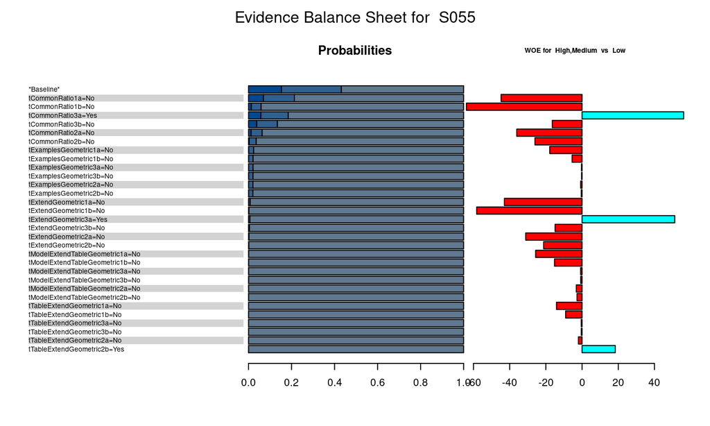

```r
woeBal(Student.History,c("High","Medium"),"Low",
       title=paste("Evidence Balance Sheet for ",
                   rownames(miniACED.data)[Student.row]))
```

## For More information

```r
help(RNetica)
help(package="RNetica")
help(CPTtools)
help(package="CPTtools")
```